# School Leaders Group Analysis

Tony Daza

2023-05-02

**Importing Data**

# Examining School leaders race by locale

```r
leader_race_cols <- c("leader1_race", "leader2_race", "leader3_race", "leader4_race", "leader5_race", "leader6_race", "leader7_race", "leader8_race", "leader9_race", "leader10_race", "leader11_race")

leader_char <- confidential

# Loop to recode race data for all the leaders
for (col_name in leader_race_cols) {
  leader_char <- leader_char %>%
      mutate(!!col_name := recode(!!sym(col_name),
            "0" = "Prefer not to say",
            "1" = "American Indian or Alaska Native",
            "2" = "Asian",
            "3" = "Black or African American",
            "4" = "Hispanic or Latinx",
            "5" = "Native Hawaiian or Pacific Islander",
            "6" = "White",
            #"7" = as.character("leader1_self_identify_text"),
            "1,2,4,6" = "American Indian or Alaska Native, Asian, Hispanic or Latinx, White",
            "1,3" = "American Indian or Alaska Native, Black or African American",
            "1,3,4,6" = "American Indian or Alaska Native, Black or African American, Hispanic or Latinx, White",
            "1,4" = "American Indian or Alaska Native, Hispanic or Latinx",
            "1,6" = "American Indian or Alaska Native, White",
            "2,3,4,6" = "Asian, Black or African American, Hispanic or Latinx, White",
            "2,3,6" = "Asian,Black or African American, White",
            "2,6" = "Asian, White",
            "3,4" = "Black or African American, Hispanic or Latinx",
            "3,4,6" = "Black or African American, Hispanic or Latinx, White",
            "3,6" = "Black or African American, White",
            "4,6" = "Hispanic or Latinx, White"
              ))
}

# Sorry this is clunky but I was struggling with getting it to work in a loop
# This just recodes the #7 self identifying text

leader_char <- leader_char %>%
  mutate(leader1_race =recode(leader1_race,
                              "7" = as.character(leader1_race_self_identify_text)))
```

```r
# Recoding the school leadership percentages
leader_char <- leader_char %>%
      mutate(leadership_diversity = recode(leadership_diversity,
"0" = "Prefer not to say",
"1" = "0 - 24% people of color",
"2" = "25 - 49% people of color",
"3" = "50 - 74% people of color",
"4" = "75 - 100% people of color",
"5" = "Not sure",))
```

```r
# Recoding the location variables for rural schools
schools_char <- schools %>%
  mutate(rural = recode(self_reported_locale_rural,
                                             "0" = "No",
                                             "1" = "Yes"))
# Recoding the location variables for suburban schools
schools_char <- schools_char %>%
  mutate(suburban = recode(self_reported_locale_suburban,
                                             "0" = "No",
                                             "1" = "Yes"))
# Recoding the location variables for urban schools
schools_char <- schools_char %>%
  mutate(urban = recode(self_reported_locale_urban,
                                             "0" = "No",
                                             "1" = "Yes"))

# Recoding the location variables into one location column
schools_char <- schools_char %>%
  mutate(location = case_when(
    rural == "Yes" & urban == "No" & suburban == "No" ~ "Rural",
    rural == "No" & urban == "Yes" & suburban == "No" ~ "Urban",
    rural == "No" & urban == "No" & suburban == "Yes" ~ "Suburban",
    TRUE ~ "Multiple"  # add an "Other" category for rows that don't fit any of the above conditions
  ))
```

From Anwesha’s code **Recoding gender for the school leaders**

```r
leader_gen_cols <- c("leader1_gender", "leader2_gender", "leader3_gender", "leader4_gender", "leader5_gender", "leader6_gender", "leader7_gender", "leader8_gender", "leader9_gender", "leader10_gender", "leader11_gender")

# Renaming for visualization/interpretation
for (col_name in leader_gen_cols) {
leader_char <- leader_char %>%
  mutate(!!col_name := recode(!!sym(col_name),
            "1" = "Man",
            "2" = "Woman",
           #"5" = as.character(leader1_gender_self_identify_text),
            "0" = "Prefer not to say",
            "3" = "Non-binary/gender-nonconforming",
            "1,2" = "Man and/or Woman",
            "1,2,3,4" = "All and/or Transgender"
  ))
}

#looks like self-identify text might have been reported in the wrong column, so recoding that one manually
leader_char$leader1_gender[leader_char$leader1_gender_self_identify_text == 1] <- "Man"


#Once again I was having difficulty with the loop for the self-identifying text
leader_char <- leader_char %>%
  mutate(leader1_gender =recode(leader1_gender,
                              "5" = as.character(leader1_gender_self_identify_text)))
```

```r
# Reducing the datasets and combining into one dataset to answer the question
school_lead_div <- schools_char %>% select(c(1,3,5:7,20,44,46:55,65,70))

leader_char_div_gen <- leader_char %>% select(c(1,2,4,6:26))

school_lead_div_gen <- school_lead_div %>% merge(leader_char_div_gen, by="school_id")
```

```r
# Split multi-race columns into separate columns
school_lead_div_wide <- school_lead_div_gen %>%
  separate(leader1_race, into = paste0("leader1_race_", 1:4), sep = ",", remove = FALSE) %>%
  separate(leader2_race, into = paste0("leader2_race_", 1:3), sep = ",", remove = FALSE) %>%
  separate(leader3_race, into = paste0("leader3_race_", 1:3), sep = ",", remove = FALSE) %>%
  separate(leader4_race, into = paste0("leader4_race_", 1:3), sep = ",", remove = FALSE) %>%
  separate(leader5_race, into = paste0("leader5_race_", 1:3), sep = ",", remove = FALSE) %>%
  separate(leader6_race, into = paste0("leader6_race_", 1:3), sep = ",", remove = FALSE) %>%
  separate(leader7_race, into = paste0("leader7_race_", 1:3), sep = ",", remove = FALSE) %>%
  separate(leader8_race, into = paste0("leader8_race_", 1:3), sep = ",", remove = FALSE) %>%
  separate(leader9_race, into = paste0("leader9_race_", 1:3), sep = ",", remove = FALSE) %>%
  separate(leader10_race, into = paste0("leader10_race_", 1:3), sep = ",", remove = FALSE) %>%
  separate(leader11_race, into = paste0("leader11_race_", 1:3), sep = ",", remove = FALSE)



# This changes the columns to factors as I was receiving an error beforehand

col_names <- names(school_lead_div_wide[18:74])
school_lead_div_wide[col_names] <- lapply(school_lead_div_wide[col_names] , factor)

# Create binary columns for each school leader indicating whether they are BIPOC or not
# Corrected so that it is counting correctly for individuals with multiple identities but not over counting by double counting each ethnicity

school_lead_div_gen <- school_lead_div_wide %>%
  mutate(
  leader1_bipoc = case_when(
    leader1_race_1 %in% c("American Indian or Alaska Native", "Asian", "Black or African American", "Hispanic or Latinx", "Native Hawaiian or Pacific Islander") |
    leader1_race_2 %in% c("American Indian or Alaska Native", "Asian", "Black or African American", "Hispanic or Latinx", "Native Hawaiian or Pacific Islander") |
    leader1_race_3 %in% c("American Indian or Alaska Native", "Asian", "Black or African American", "Hispanic or Latinx", "Native Hawaiian or Pacific Islander") |
  leader1_race_4 %in% c("American Indian or Alaska Native", "Asian", "Black or African American", "Hispanic or Latinx", "Native Hawaiian or Pacific Islander") ~ 1,
    TRUE ~ 0
  ),
    leader2_bipoc = case_when(
      leader2_race_1 %in% c("American Indian or Alaska Native", "Asian", "Black or African American", "Hispanic or Latinx", "Native Hawaiian or Pacific Islander") |
      leader2_race_2 %in% c("American Indian or Alaska Native", "Asian", "Black or African American", "Hispanic or Latinx", "Native Hawaiian or Pacific Islander") |
      leader1_race_3 %in% c("American Indian or Alaska Native", "Asian", "Black or African American", "Hispanic or Latinx", "Native Hawaiian or Pacific Islander") ~ 1,
      TRUE ~ 0
    ),
    leader3_bipoc = case_when(
      leader3_race_1 %in% c("American Indian or Alaska Native", "Asian", "Black or African American", "Hispanic or Latinx", "Native Hawaiian or Pacific Islander") |
      leader3_race_2 %in% c("American Indian or Alaska Native", "Asian", "Black or African American", "Hispanic or Latinx", "Native Hawaiian or Pacific Islander") |
      leader3_race_3 %in% c("American Indian or Alaska Native", "Asian", "Black or African American", "Hispanic or Latinx", "Native Hawaiian or Pacific Islander") ~ 1,
      TRUE ~ 0
    ),
    leader4_bipoc = case_when(
      leader4_race_1 %in% c("American Indian or Alaska Native", "Asian", "Black or African American", "Hispanic or Latinx", "Native Hawaiian or Pacific Islander") |
      leader4_race_2 %in% c("American Indian or Alaska Native", "Asian", "Black or African American", "Hispanic or Latinx", "Native Hawaiian or Pacific Islander") |
      leader4_race_3 %in% c("American Indian or Alaska Native", "Asian", "Black or African American", "Hispanic or Latinx", "Native Hawaiian or Pacific Islander") ~ 1,
      TRUE ~ 0
    ),
    leader5_bipoc = case_when(
      leader5_race_1 %in% c("American Indian or Alaska Native", "Asian", "Black or African American", "Hispanic or Latinx", "Native Hawaiian or Pacific Islander") |
      leader5_race_2 %in% c("American Indian or Alaska Native", "Asian", "Black or African American", "Hispanic or Latinx", "Native Hawaiian or Pacific Islander") |
      leader5_race_3 %in% c("American Indian or Alaska Native", "Asian", "Black or African American", "Hispanic or Latinx", "Native Hawaiian or Pacific Islander") ~ 1,
      TRUE ~ 0
    ),
    leader6_bipoc = case_when(
      leader6_race_1 %in% c("American Indian or Alaska Native", "Asian", "Black or African American", "Hispanic or Latinx", "Native Hawaiian or Pacific Islander") |
      leader6_race_2 %in% c("American Indian or Alaska Native", "Asian", "Black or African American", "Hispanic or Latinx", "Native Hawaiian or Pacific Islander") |
      leader6_race_3 %in% c("American Indian or Alaska Native", "Asian", "Black or African American", "Hispanic or Latinx", "Native Hawaiian or Pacific Islander") ~ 1,
      TRUE ~ 0
    ),
    leader7_bipoc = case_when(
      leader7_race_1 %in% c("American Indian or Alaska Native", "Asian", "Black or African American", "Hispanic or Latinx", "Native Hawaiian or Pacific Islander") |
      leader7_race_2 %in% c("American Indian or Alaska Native", "Asian", "Black or African American", "Hispanic or Latinx", "Native Hawaiian or Pacific Islander") |
      leader7_race_3 %in% c("American Indian or Alaska Native", "Asian", "Black or African American", "Hispanic or Latinx", "Native Hawaiian or Pacific Islander") ~ 1,
      TRUE ~ 0
    ),
    leader8_bipoc = case_when(
      leader8_race_1 %in% c("American Indian or Alaska Native", "Asian", "Black or African American", "Hispanic or Latinx", "Native Hawaiian or Pacific Islander") |
      leader8_race_2 %in% c("American Indian or Alaska Native", "Asian", "Black or African American", "Hispanic or Latinx", "Native Hawaiian or Pacific Islander") |
      leader8_race_3 %in% c("American Indian or Alaska Native", "Asian", "Black or African American", "Hispanic or Latinx", "Native Hawaiian or Pacific Islander") ~ 1,
      TRUE ~ 0
    ),
    leader9_bipoc = case_when(
      leader9_race_1 %in% c("American Indian or Alaska Native", "Asian", "Black or African American", "Hispanic or Latinx", "Native Hawaiian or Pacific Islander") |
      leader9_race_2 %in% c("American Indian or Alaska Native", "Asian", "Black or African American", "Hispanic or Latinx", "Native Hawaiian or Pacific Islander") |
      leader9_race_3 %in% c("American Indian or Alaska Native", "Asian", "Black or African American", "Hispanic or Latinx", "Native Hawaiian or Pacific Islander") ~ 1,
      TRUE ~ 0
    ),
    leader10_bipoc = case_when(
      leader10_race_1 %in% c("American Indian or Alaska Native", "Asian", "Black or African American", "Hispanic or Latinx", "Native Hawaiian or Pacific Islander") |
      leader10_race_2 %in% c("American Indian or Alaska Native", "Asian", "Black or African American", "Hispanic or Latinx", "Native Hawaiian or Pacific Islander") |
      leader10_race_3 %in% c("American Indian or Alaska Native", "Asian", "Black or African American", "Hispanic or Latinx", "Native Hawaiian or Pacific Islander") ~ 1,
      TRUE ~ 0
    ),
    leader11_bipoc = case_when(
      leader11_race_1 %in% c("American Indian or Alaska Native", "Asian", "Black or African American", "Hispanic or Latinx", "Native Hawaiian or Pacific Islander") |
      leader11_race_2 %in% c("American Indian or Alaska Native", "Asian", "Black or African American", "Hispanic or Latinx", "Native Hawaiian or Pacific Islander") |
      leader11_race_3 %in% c("American Indian or Alaska Native", "Asian", "Black or African American", "Hispanic or Latinx", "Native Hawaiian or Pacific Islander") ~ 1,
      TRUE ~ 0
    ))


# This changes the columns back to character as I was receiving an error when trying to sum the rows

school_lead_div_gen <- school_lead_div_gen %>%
  mutate(across(leader1_gender:leader11_race, as.character))
############################################################################

# Summing bipoc leaders per school
school_lead_div_gen <- school_lead_div_gen %>%
  mutate(
    bipoc_leader_count = rowSums(across(leader1_bipoc:leader11_bipoc)))

# Removing the separated race columns
school_lead_div_gen <- school_lead_div_gen %>% select(-c(22:25,28:30,33:35,38:40,43:45,48:50,53:55,58:60,63:65,68:70,73:75))

# Summing total leader count by school
school_lead_div_gen <- school_lead_div_gen %>%
  mutate(total_leader_count = rowSums(across(c(21,23,25,27,29,31,33,35,37,39,41), ~ !is.na(.))))
```

In reviewing this I realized that school leaders who listed race as NA but included a gender, suggesting that they existed, resulted in the school leader not being counted. Unfortunately, this results in the percentages of BIPOC leaders being off.

```r
# None of the primary leaders had race but no gender
race_but_no_gender <- school_lead_div_gen %>%
  filter(!is.na(leader1_race) & is.na(leader1_gender))

# 6 of the primary leaders had gender but no race
# These are the schools that need to be corrected for their counts
# Plus we need to find the one other school leader that reported gender but not race.
# Interestingly most of those leaders identify as transgender.
gender_but_no_race <- school_lead_div_gen %>%
  filter(!is.na(leader1_gender) & is.na(leader1_race))

## Found the other school leader
## Hamilton High School, both school leaders put prefer not to say for gender and school leader 1 also put prefer not to say for race.
## School leader 2 only had prefer not to say for gender.
## Total leader count needs to updated.
## Hamilton High School: ID # 650

# school_lead_div_gen %>%
#   filter(!is.na(leader2_gender) & is.na(leader2_race))




# count how many times race is filled out but gender is NA
race_no_gender_count <- school_lead_div_gen %>%
  filter(!is.na(leader1_race) & is.na(leader1_gender) |
           !is.na(leader2_race) & is.na(leader2_gender) |
           !is.na(leader3_race) & is.na(leader3_gender) |
           !is.na(leader4_race) & is.na(leader4_gender) |
           !is.na(leader5_race) & is.na(leader5_gender) |
           !is.na(leader6_race) & is.na(leader6_gender) |
           !is.na(leader7_race) & is.na(leader7_gender) |
           !is.na(leader8_race) & is.na(leader8_gender) |
           !is.na(leader9_race) & is.na(leader9_gender) |
           !is.na(leader10_race) & is.na(leader10_gender) |
           !is.na(leader11_race) & is.na(leader11_gender)) %>%
  nrow()

# count how many times gender is filled out but race is NA
gender_no_race_count <- school_lead_div_gen %>%
  filter(is.na(leader1_race) & !is.na(leader1_gender) |
           is.na(leader2_race) & !is.na(leader2_gender) |
           is.na(leader3_race) & !is.na(leader3_gender) |
           is.na(leader4_race) & !is.na(leader4_gender) |
           is.na(leader5_race) & !is.na(leader5_gender) |
           is.na(leader6_race) & !is.na(leader6_gender) |
           is.na(leader7_race) & !is.na(leader7_gender) |
           is.na(leader8_race) & !is.na(leader8_gender) |
           is.na(leader9_race) & !is.na(leader9_gender) |
           is.na(leader10_race) & !is.na(leader10_gender) |
           is.na(leader11_race) & !is.na(leader11_gender)) %>%
  nrow()

# print the results
cat(paste("Race, no gender:", race_no_gender_count, "\n"))
```

```
## Race, no gender: 12
```

```r
cat(paste("Gender, no race:", gender_no_race_count, "\n"))
```

```
## Gender, no race: 7
```

This tells me there are 12 school leaders that had race but not gender and 7 that had gender but not race. That means my counts for school leaders is off by 7, but I am not sure where exactly. I will have to dig deeper.

```r
# Individually fixing the school leader total count for the schools where gender but not race was reported.


school_fix <- c("37","247", "318", "448", "535", "650", "777")

# Loop to recode total leader counts manualls
for (col_name in leader_race_cols) {

school_lead_div_gen %>%
  filter(school_lead_div_gen$school_id == 650) %>%
  mutate(total_leader_count = total_leader_count +1)

}

school_lead_div_gen$total_leader_count[school_lead_div_gen$school_id == 650] <- 2
school_lead_div_gen$total_leader_count[school_lead_div_gen$school_id == 37] <- 11
school_lead_div_gen$total_leader_count[school_lead_div_gen$school_id == 247] <- 1
school_lead_div_gen$total_leader_count[school_lead_div_gen$school_id == 318] <- 2
school_lead_div_gen$total_leader_count[school_lead_div_gen$school_id == 448] <- 3
school_lead_div_gen$total_leader_count[school_lead_div_gen$school_id == 535] <- 3
school_lead_div_gen$total_leader_count[school_lead_div_gen$school_id == 777] <- 6

school_lead_div_gen$total_leader_count <- as.numeric(school_lead_div_gen$total_leader_count)

# Determining bipoc leader percent
school_lead_div_gen <- school_lead_div_gen %>%
  mutate(bipoc_leader_pct = bipoc_leader_count / total_leader_count * 100)
```

## Data table BIPOC leaders by Locale

```r
library(DT)
library(dplyr)

# Count the number of BIPOC school leaders for each school type

school_lead_div_sum <- school_lead_div_gen %>%
  group_by(exclusive_locale) %>%
  dplyr::summarize(
    total_leader_count = sum(total_leader_count),
    bipoc_leader_count = sum(across(leader1_bipoc:leader11_bipoc)),
    bipoc_leader_pct = round(bipoc_leader_count / total_leader_count * 100,digits=2))



DT::datatable(school_lead_div_sum)
```

|  | exclusive_locale | total_leader_count | bipoc_leader_count | bipoc_leader_pct |
| --- | --- | --- | --- | --- |
| 1 | Multiple | 97 | 26 | 26.8 |
| 2 | Rural | 149 | 32 | 21.48 |
| 3 | Suburban | 113 | 25 | 22.12 |
| 4 | Urban | 513 | 262 | 51.07 |

## Bar graph BIPOC Leader by Locale

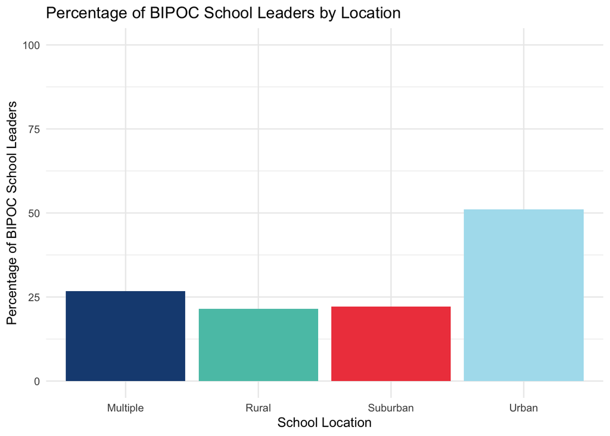

```r
school_lead_div_sum %>%
  group_by(exclusive_locale) %>%
  ggplot(aes(x = exclusive_locale, y = bipoc_leader_pct)) +
  geom_bar(stat = "identity", fill = transcend_cols) +
  labs(x = "School Location", y = "Percentage of BIPOC School Leaders",
       title = "Percentage of BIPOC School Leaders by Location")+
  scale_y_continuous(limits = c(0,100))+
  theme_minimal()
```

# BIPOC Leader by locale

## Regression Model BIPOC Leader by Locale

```r
library(sjPlot)
# Run a linear regression model for location data
locale_model <- lm(bipoc_leader_pct ~ exclusive_locale, data = school_lead_div_gen)

# Model summary
summary(locale_model)
```

```
##
## Call:
## lm(formula = bipoc_leader_pct ~ exclusive_locale, data = school_lead_div_gen)
##
## Residuals:
##    Min     1Q Median     3Q    Max
## -48.81 -23.81 -11.31  29.11  79.62
##
## Coefficients:
##                          Estimate Std. Error t value Pr(>|t|)
## (Intercept)                25.455      6.252   4.072 6.29e-05 ***
## exclusive_localeRural      -5.076      8.193  -0.620 0.536124
## exclusive_localeSuburban   -4.560      8.983  -0.508 0.612141
## exclusive_localeUrban      23.356      6.945   3.363 0.000893 ***
## ---
## Signif. codes:  0 '***' 0.001 '**' 0.01 '*' 0.05 '.' 0.1 ' ' 1
##
## Residual standard error: 35.91 on 247 degrees of freedom
## Multiple R-squared:  0.1233, Adjusted R-squared:  0.1127
## F-statistic: 11.58 on 3 and 247 DF,  p-value: 3.957e-07
```

```r
tab_model(locale_model)
```

|  | bipoc leader pct |  |  |
| --- | --- | --- | --- |
| Predictors | Estimates | CI | p |
| (Intercept) | 25.45 | 13.14 – 37.77 | **<0.001** |
| exclusive locale [Rural] | -5.08 | -21.21 – 11.06 | 0.536 |
| exclusive locale [Suburban] | -4.56 | -22.25 – 13.13 | 0.612 |
| exclusive locale [Urban] | 23.36 | 9.68 – 37.03 | **0.001** |
| Observations | 251 |  |  |
| R<sup>2</sup> / R<sup>2</sup> adjusted | 0.123 / 0.113 |  |  |

## ANOVA model

**It was recommended to use an ANOVA model instead** In the regression the multiple location was the comparison group, but that was not all that useful so an ANOVA will allow us to look at the differences between the groups

```r
locale_aov <- aov(bipoc_leader_pct ~ exclusive_locale, data = school_lead_div_gen)
summary.aov(locale_aov)
```

```
##                   Df Sum Sq Mean Sq F value   Pr(>F)
## exclusive_locale   3  44814   14938   11.58 3.96e-07 ***
## Residuals        247 318558    1290
## ---
## Signif. codes:  0 '***' 0.001 '**' 0.01 '*' 0.05 '.' 0.1 ' ' 1
```

```r
locale_pairs <- TukeyHSD(locale_aov)
locale_pairs
```

```
##   Tukey multiple comparisons of means
##     95% family-wise confidence level
##
## Fit: aov(formula = bipoc_leader_pct ~ exclusive_locale, data = school_lead_div_gen)
##
## $exclusive_locale
##                         diff        lwr      upr     p adj
## Rural-Multiple    -5.0757576 -26.266883 16.11537 0.9257644
## Suburban-Multiple -4.5601173 -27.794360 18.67413 0.9572106
## Urban-Multiple    23.3559250   5.392694 41.31916 0.0049196
## Suburban-Rural     0.5156403 -21.069852 22.10113 0.9999151
## Urban-Rural       28.4316826  12.658887 44.20448 0.0000302
## Urban-Suburban    27.9160423   9.489232 46.34285 0.0006633
```

```r
#As expected, it is pretty clear that Urban is significantly different than the others (Multiple, rural, and suburban) in terms of percent of bipoc school leaders. None of the other locales were significantly different from each other.
```

As expected, based on the bipoc leader percentage summaries and the graph, it is pretty clear that Urban is significantly different than the others (Multiple, rural, and suburban) in terms of percent of bipoc school leaders. None of the other locales were significantly different from each other.

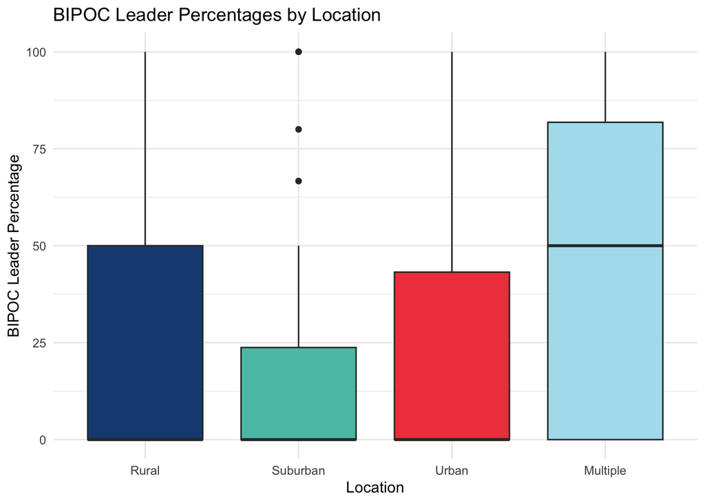

```r
# Regression Model graph

school_lead_div_gen %>%
  ggplot(aes(x = exclusive_locale, y = bipoc_leader_pct)) +
  geom_boxplot(fill = transcend_cols) +
  labs(x = "Location", y = "BIPOC Leader Percentage", title = "BIPOC Leader Percentages by Location") +
  scale_x_discrete(labels = c("Rural", "Suburban", "Urban", "Multiple")) +
  theme_minimal()
```

Of the three schools there is a little bit of confusion as one school, Gem Prep Nampa, reported three school leaders, 2 of which where bipoc, resulting in a calculated percent bipoc school leaders of 66% but their reported percentage of diverse school leaders was 0-24%.

The other school, Ke Kula ’o Samuel M. Kamakau, had three school leaders as well but one did not report their race resulting in a calculated percent bipoc of 66% for their school leaders, but their self-reported percent leaders of color was 75-100%.

Finally, The leadership school in Missouri had three school leaders who identified as Black or African American, which does seem like an outlier for suburban schools.

# School Leader distributions

## Total count distribution

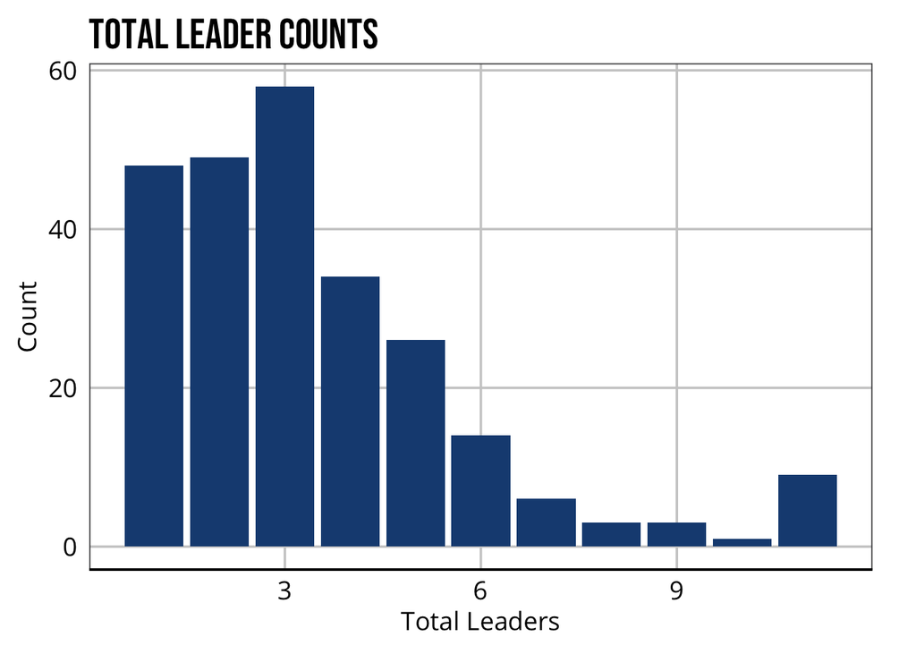

```r
# Want to look at how many schools reported different number of leaders

#Distribution of reported total school leaders across all schools
school_lead_div_gen %>%
  ggplot(aes(x = total_leader_count)) +
  geom_bar(fill="#1A4C81") +
  xlab("Total Leaders") +
  ylab("Count")+
  theme(legend.position = "none")+
  labs(title = "Total Leader Counts")
```

## Total count distribution by location

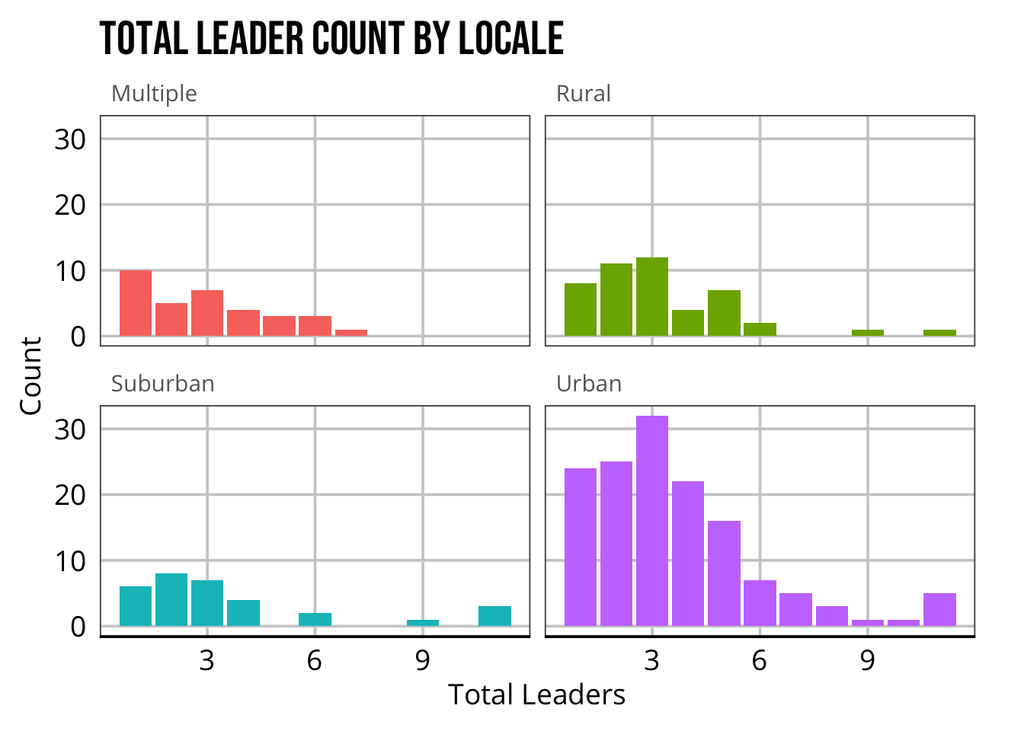

```r
# Looking at the number of leaders by location
# Can't get the color right on this one
# Can probably use a manual fill for color
school_lead_div_gen %>%
  ggplot(aes(x = total_leader_count)) +
  geom_bar(aes(fill = exclusive_locale)) +
  facet_wrap(~ exclusive_locale) +
  xlab("Total Leaders") +
  ylab("Count")+
  theme(legend.position = "none")+
  labs(title = "Total Leader Count by Locale", x = "Total Leaders", y = "Count")
```

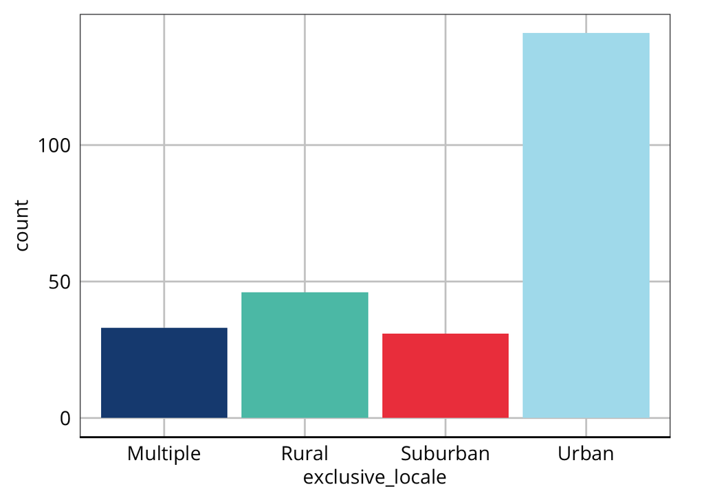

```r
# School distribution by location

school_lead_div_gen %>%
  ggplot(aes(x=exclusive_locale))+
  geom_bar(fill=transcend_cols)
```

```r
locale <- full %>%
  select(school_name, exclusive_locale) %>%
  mutate(rate = rep(1, 251)) %>%
  group_by(exclusive_locale) %>%
  summarize(N = sum(rate)) %>%
  rename(`Geographic Locale` = exclusive_locale)

#########################################################

locale_state <- full %>%
  select(school_name, exclusive_locale, school_state) %>%
  mutate(rate = rep(1, 251)) %>%
  group_by(exclusive_locale, school_state) %>%
  summarize(N = sum(rate)) %>%
  rename(`Geographic Locale` = exclusive_locale,
         `State` = school_state)
#########################################################

# I am stuck on counting this one correctly

# locale_level <- full %>%
#   select(starts_with("grades_"), school_name, exclusive_locale) %>%
#   group_by(exclusive_locale) %>%
#   mutate(across(starts_with("grades_"), ~ sum(.x, na.rm = TRUE))) %>%
#   pivot_longer(cols = starts_with("grades"),
#                names_to = "School level",
#                values_to = "N") %>%
#   group_by(exclusive_locale, `School level`) %>%
#   summarize(N = n()) %>%
#   rename(`Geographic Locale` = exclusive_locale)

#########################################################

locale_level_state <- full %>%
  select(starts_with("grades_"), school_name, exclusive_locale, school_state) %>%
  group_by(exclusive_locale, school_state) %>%
  mutate(across(starts_with("grades_"), ~ sum(.x, na.rm = TRUE))) %>%
  pivot_longer(cols = starts_with("grades"),
               names_to = "School level",
               values_to = "N") %>%
  group_by(exclusive_locale, school_state, `School level`) %>%
  summarize(N = sum(N)) %>%
  rename(`Geographic Locale` = exclusive_locale,
         `School state` = school_state)
#########################################################
```

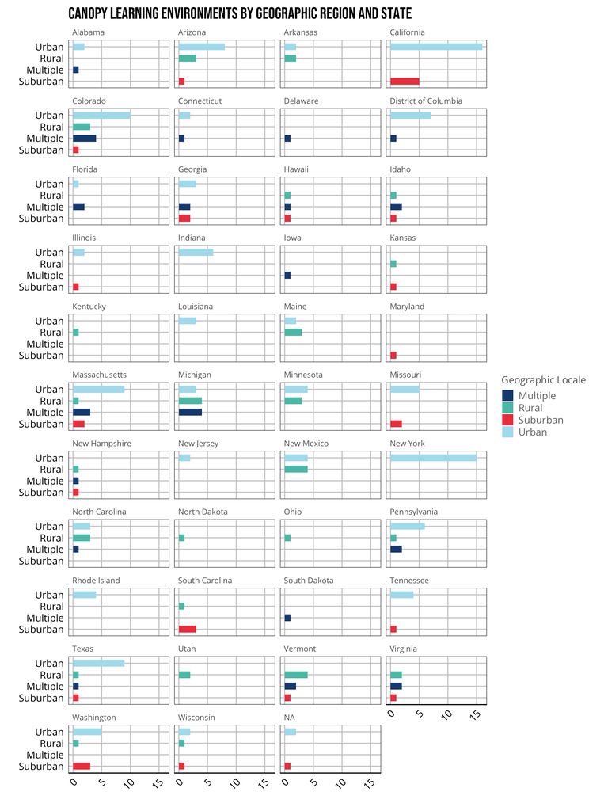

```r
# ggplot(locale_state, aes(reorder(`Geographic Locale`, N), N, fill = `Geographic Locale`)) +
#   geom_col(position = "dodge") +
#   scale_fill_manual(values = transcend_cols) +
#   scale_y_continuous(limits=c(0, 150), expand = c(0,0)) +
#   labs(title = "Canopy Learning Environments by Geographic Region",
#        x = "",
#        y = "") +
#   theme(legend.position = "none", axis.text.x = element_text(angle = 45, hjust = 1)) +
#     geom_text(aes(label = signif(N)),
#             nudge_y = 3,
#             color = "black",
#             fontface = "bold",
#             size = 5,
#             family = "sans")



locale_state %>%
  ggplot(aes(x = reorder(`Geographic Locale`, N), y = N, fill = `Geographic Locale`)) +
  geom_col(position = "dodge") +
  scale_fill_manual(values = transcend_cols) +
  facet_wrap(~State, ncol = 4, nrow = 11) +
  theme(axis.text.x = element_text(angle = 45, hjust = 1)) +
  coord_flip() +
  labs(title = "Canopy Learning Environments by Geographic Region and State",
       x = "",
       y = "")
```

```r
# As I couldn't get the filtering to work, this also doesn't work.

# locale_level %>%
#   ggplot(aes(x = reorder(`Geographic Locale`, N), y = N, fill = `School level`)) +
#   geom_col(position = "dodge") +
#   scale_fill_manual(values = transcend_cols) +
#   facet_wrap(~`School level`, ncol = 1) +
#   theme(axis.text.x = element_text(angle = 45, hjust = 1)) +
#   coord_flip() +
#   labs(title = "Canopy Learning Environments by Geographic Region and School Level",
#        x = "",
#        y = "")
```

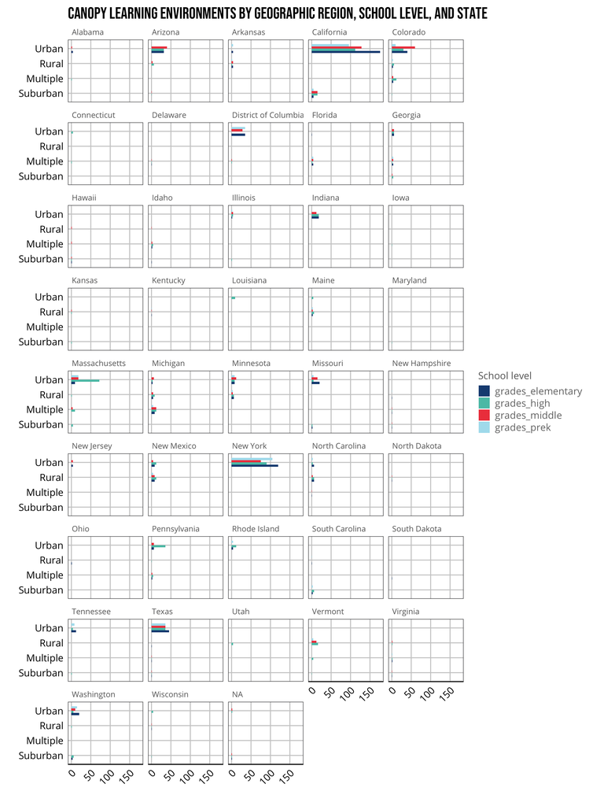

```r
locale_level_state %>%
  ggplot(aes(x = reorder(`Geographic Locale`, N), y = N, fill = `School level`)) +
  geom_col(position = "dodge") +
  scale_fill_manual(values = transcend_cols) +
  facet_wrap(~`School state`, ncol = 5, nrow = 10) +
  theme(axis.text.x = element_text(angle = 45, hjust = 1)) +
  coord_flip() +
  labs(title = "Canopy Learning Environments by Geographic Region, School Level, and State",
       x = "",
       y = "")
```

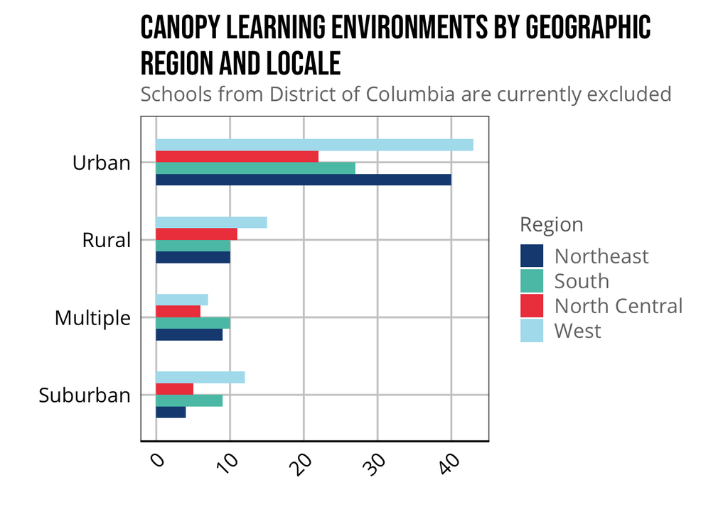

```r
library(datasets)

regions <- as.data.frame(state.region)
regions <- regions %>% mutate(State_ID = row_number())

states <- as.data.frame(state.name)
states <- states %>% mutate(State_ID = row_number())

# I realized that this data set doesn't have the District of Columbia
# It leads to some NA values
# I will sort them out later and for now just filter them out

regions <- full_join(states, regions, by = "State_ID")
regions <- regions %>% select(-"State_ID")
regions <- regions %>% rename(school_state = state.name,
                              school_region = state.region)

full_region <- left_join(full, regions, by = "school_state")




locale_region <- full_region %>%
  select(school_name, exclusive_locale, school_region) %>%
  mutate(rate = rep(1, 251)) %>%
  filter(!is.na(school_region)) %>%
  group_by(exclusive_locale, school_region) %>%
  summarize(N = sum(rate, na.rm = TRUE)) %>%
  rename(`Geographic Locale` = exclusive_locale,
         `Region` = school_region)
locale_region %>%
  ggplot(aes(x = reorder(`Geographic Locale`, N), y = N, fill = `Region`)) +
  geom_col(position = "dodge") +
  scale_fill_manual(values = transcend_cols) +
  theme(axis.text.x = element_text(angle = 45, hjust = 1)) +
  coord_flip() +
  labs(title = "Canopy Learning Environments by Geographic \nRegion and Locale",
       subtitle = "Schools from District of Columbia are currently excluded",
       x = "",
       y = "")
```